# Reproducible Research - Course Project 1

John Kirker

February 6, 2016

## Load and preprocess the data

```r
data = read.csv("activity.csv")
```

## Clean the data

```r
data$day = weekdays(as.Date(data$date))
data$DateTime = as.POSIXct(data$date, format = "%Y-%m-%d")
head(data)
```

```
##   steps       date interval    day   DateTime
## 1    NA 2012-10-01        0 Monday 2012-10-01
## 2    NA 2012-10-01        5 Monday 2012-10-01
## 3    NA 2012-10-01       10 Monday 2012-10-01
## 4    NA 2012-10-01       15 Monday 2012-10-01
## 5    NA 2012-10-01       20 Monday 2012-10-01
## 6    NA 2012-10-01       25 Monday 2012-10-01
```

Remove NA’s

```r
cleandata = data[!is.na(data$steps),]
head(cleandata)
```

```
##     steps       date interval     day   DateTime
## 289     0 2012-10-02        0 Tuesday 2012-10-02
## 290     0 2012-10-02        5 Tuesday 2012-10-02
## 291     0 2012-10-02       10 Tuesday 2012-10-02
## 292     0 2012-10-02       15 Tuesday 2012-10-02
## 293     0 2012-10-02       20 Tuesday 2012-10-02
## 294     0 2012-10-02       25 Tuesday 2012-10-02
```

Process data for plotting

```r
library(ggplot2)
library(dplyr)
steps <- cleandata %>%
  filter(!is.na(steps)) %>%
  group_by(date) %>%
  summarize(steps = sum(steps)) %>%
  print
```

```
## Source: local data frame [53 x 2]
##
##          date steps
##        (fctr) (int)
## 1  2012-10-02   126
## 2  2012-10-03 11352
## 3  2012-10-04 12116
## 4  2012-10-05 13294
## 5  2012-10-06 15420
## 6  2012-10-07 11015
## 7  2012-10-09 12811
## 8  2012-10-10  9900
## 9  2012-10-11 10304
## 10 2012-10-12 17382
## ..        ...   ...
```

Plot histogram - frequency of steps per day

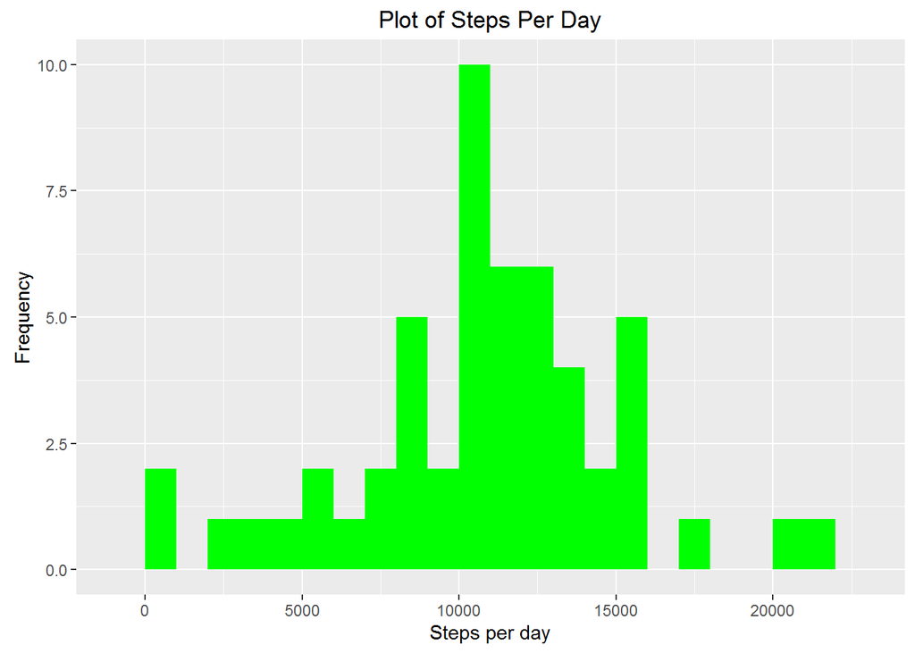

```r
ggplot(steps, aes(x = steps)) +
  geom_histogram(fill = "green", binwidth = 1000) +
  labs(title = "Plot of Steps Per Day", x = "Steps per day", y = "Frequency")
```

## What is mean total number of steps taken per day?

```r
stepmu = mean(steps$steps, na.rm = TRUE)
stepmed = median(steps$steps, na.rm = TRUE)
stepmu  ##step mean
```

```
## [1] 10766.19
```

```r
stepmed  ##step median
```

```
## [1] 10765
```

**Mean steps == 10766.19 and median steps == 10765.**

## What is the average daily activity pattern?

```r
interval = data %>%
  filter(!is.na(steps)) %>%
  group_by(interval) %>%
  summarize(steps = mean(steps))
print
```

```
## function (x, ...)
## UseMethod("print")
## <bytecode: 0x0000000013eb9fa0>
## <environment: namespace:base>
```

Make a time series plot (i.e. type = “l”) of the 5-minute interval (x-axis) and the average number of steps taken, averaged across all days (y-axis)

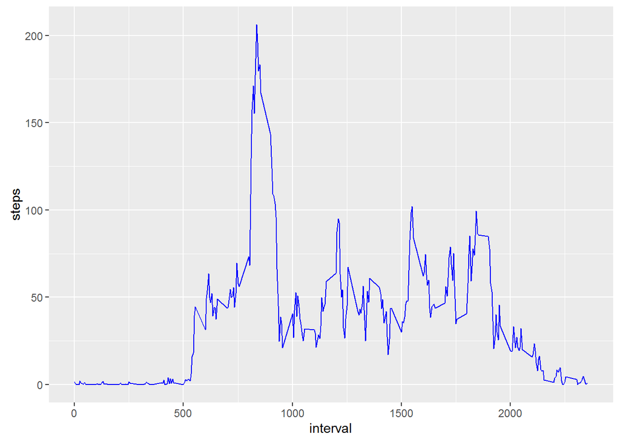

```r
ggplot(interval, aes(x=interval, y=steps)) +
  geom_line(color = "blue")
```

Which 5-minute interval, on average across all the days in the dataset, contains the maximum number of steps?

```r
interval[which.max(interval$steps),]
```

```
## Source: local data frame [1 x 2]
##
##   interval    steps
##      (int)    (dbl)
## 1      835 206.1698
```

**Interval 835 has the greatest number of steps with 206.17**

## Imputing missing values

Calculate and report the total number of missing values in the dataset (i.e. the total number of rows with NAs)

```r
sum(is.na(data$steps))
```

```
## [1] 2304
```

Devise a strategy for filling in all of the missing values in the dataset. The strategy does not need to be sophisticated. Create a new dataset that is equal to the original dataset but with the missing data filled in.

```r
datacomplete = data
nas = is.na(datacomplete$steps)
avgint  = tapply(datacomplete$steps, datacomplete$interval, mean, na.rm=TRUE, simplify=TRUE)
datacomplete$steps[nas] = avgint[as.character(datacomplete$interval[nas])]
sum(is.na(datacomplete$steps))
```

```
## [1] 0
```

**There is no more missing data.**

Make a histogram of the total number of steps taken each day and Calculate and report the mean and median total number of steps taken per day. Do these values differ from the estimates from the first part of the assignment? What is the impact of imputing missing data on the estimates of the total daily number of steps?

```r
stepscomplete = datacomplete %>%
  filter(!is.na(steps)) %>%
  group_by(date) %>%
  summarize(steps = sum(steps)) %>%
  print
```

```
## Source: local data frame [61 x 2]
##
##          date    steps
##        (fctr)    (dbl)
## 1  2012-10-01 10766.19
## 2  2012-10-02   126.00
## 3  2012-10-03 11352.00
## 4  2012-10-04 12116.00
## 5  2012-10-05 13294.00
## 6  2012-10-06 15420.00
## 7  2012-10-07 11015.00
## 8  2012-10-08 10766.19
## 9  2012-10-09 12811.00
## 10 2012-10-10  9900.00
## ..        ...      ...
```

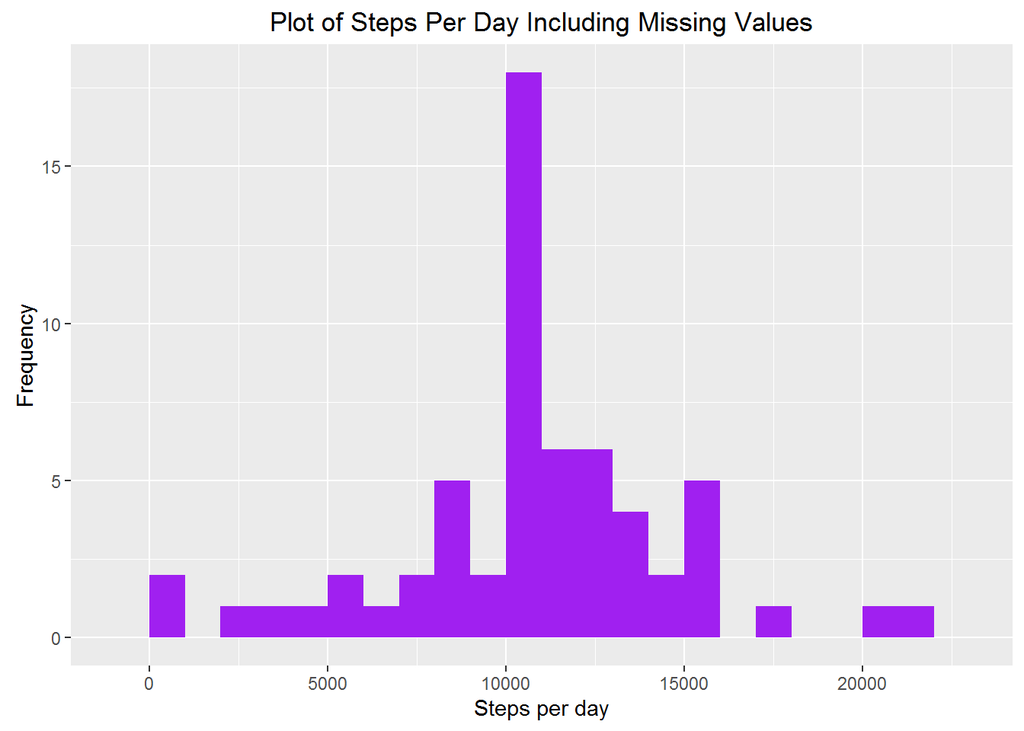

```r
ggplot(stepscomplete, aes(x = steps)) +
  geom_histogram(fill = "purple", binwidth = 1000) +
  labs(title = "Plot of Steps Per Day Including Missing Values", x = "Steps per day", y = "Frequency")
```

Calculated mean and median with missing values.

```r
allstepsmu = mean(stepscomplete$steps, na.rm = TRUE)
allstepsmedian = median(stepscomplete$steps, na.rm = TRUE)
allstepsmu
```

```
## [1] 10766.19
```

```r
allstepsmedian
```

```
## [1] 10766.19
```

**If we impute missing data, both mean and median are the same: 10766.19**

## Are there differences in activity patterns between weekdays and weekends?

Create new columnn, “timeperiod” and set to weekend (Saturday or Sunday) or weekday (Monday thru Friday)

```r
library(reshape2)
library(gridExtra)
datacomplete <- mutate(datacomplete, timeperiod = ifelse(weekdays(datacomplete$DateTime) == "Saturday" | weekdays(datacomplete$DateTime) == "Sunday", "weekend", "weekday"))
datacomplete$timeperiod = as.factor(datacomplete$timeperiod)
head(datacomplete)
```

```
##       steps       date interval    day   DateTime timeperiod
## 1 1.7169811 2012-10-01        0 Monday 2012-10-01    weekday
## 2 0.3396226 2012-10-01        5 Monday 2012-10-01    weekday
## 3 0.1320755 2012-10-01       10 Monday 2012-10-01    weekday
## 4 0.1509434 2012-10-01       15 Monday 2012-10-01    weekday
## 5 0.0754717 2012-10-01       20 Monday 2012-10-01    weekday
## 6 2.0943396 2012-10-01       25 Monday 2012-10-01    weekday
```

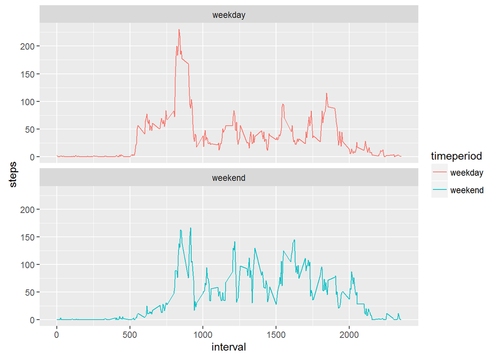

```r
intcomplete = datacomplete %>%
  group_by(interval, timeperiod) %>%
  summarize(steps = mean(steps))

ggplot(intcomplete, aes(x=interval, y=steps, color = timeperiod)) +
  geom_line() +
  facet_wrap(~timeperiod, ncol = 1, nrow=2)
```